# Lab 1: Getting Started with D3.js

CMSC471: Introduction to Information Visualization (Spring 2025)

02/05/2025

We will start our journey to explore data visualization! By the end of this lab, you will be able to:

- Use D3 selections to manipulate DOM elements
- Create SVG shapes programmatically with D3

Core D3 module to learn: [D3 Selection](https://github.com/d3/d3-selection).

**Grade: 3% of the total grade**; we grade out of 30 pts. You can submit this lab during the lab sessions or Fumeng’s office hours (W until 4:30) on the Wed Feb 5 (or Wed Feb 12).

## Part 1: Setup reminder (10 min)

### Required tools

- A text editor (VS Code recommended)
- A modern web browser (Chrome recommended)

### Local server setup

You’ll need a local server to load external files and avoid CORS issues. You have two options:

1. **Python server**:
   - Open your terminal/command prompt
   - Navigate to your project folder: `cd path/to/lab1`
   - If using Python 3: `python -m http.server 8000`
   - If using Python 2: `python -m SimpleHTTPServer 8000`
   - Open your browser and visit: `http://localhost:8000`
   - To stop the server: Press `Ctrl+C` in the terminal
2. **VS Code Live Server (highly recommended)**:
   - Install the “Live Server” extension in VS Code
   - Remember to click on `install`.
   - **Live Server** automatically updates the webpage (super convenient!!)

[figure not shown]

Go Live

### Project structure

Create a new folder named `lab1` within your `CMSC471` folder using the following structure (or you can copy and paste your `lab0`):

```
lab1/
├── index.html
├── css/
│   └── styles.css
└── js/
    └── script.js
```

### Step-by-step setup (new)

1. **Create index.html**: Free feel to copy and paste; however, you should notice that there is a `<div>` with an id of `vis`.

```html
<!DOCTYPE html>
<html lang="en">
<head>
    <meta charset="UTF-8">
    <meta name="viewport" content="width=device-width, initial-scale=1.0">
    <title>Lab 1: Intro to D3</title>
    <link rel="stylesheet" href="css/styles.css">
</head>
<body>
    <div class="container"> <!-- Centers content and sets max width -->
        <h1>Lab 1: Getting Started with D3.js</h1>
        <div id="vis"></div> <!--  Will hold our visualization (SVG) -->
    </div>

    <!-- Load D3.js -->
    <script src="https://d3js.org/d3.v7.min.js"></script>
    <script src="js/script.js"></script>
</body>
</html>
```

2. **Create styles.css**: These are generic features, but they could center your canvas and add nice paddings.

```css
/* Reset default styles */
* {
    font-family: Arial, sans-serif;
    max-width: 800px;
    margin: 0px auto;
    line-height: 1.8;
}

/* Container styling for layout */
.container {
    max-width: 800px;
    margin: 2rem auto;
    font-family: Arial, sans-serif;
}
```

3. **Test your setup**
   1. Right-click `index.html` in VS Code
   2. Select `Open with Live Server` (or the little `Go Live`) at the bottom right of your screen.
   3. Your page should automatically open in Chrome (or your default browser)

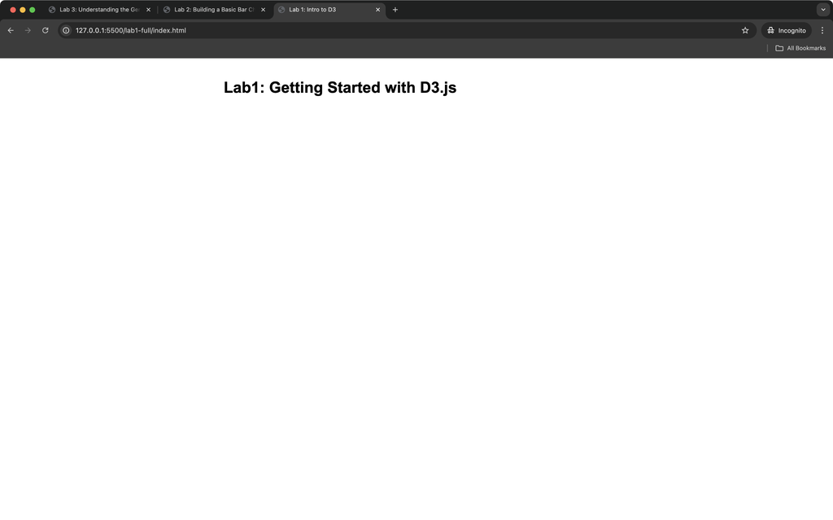

Testing your setup

## Part 2: Your first D3 code (20 min)

### Creating an SVG canvas

In `script.js`, start with (type in or at least copy them block by block):

Confirm D3 is loaded

```javascript
console.log('D3 Version:', d3.version);
```

Create SVG canvas. We select the `<div>` and `append` an svg element to it with specific parameters.

```javascript
const width = 600;
const height = 400;
const r = 50; // radius

const svg = d3.select('#vis')
    .append('svg')
    .attr('width', width)
    .attr('height', height);
```

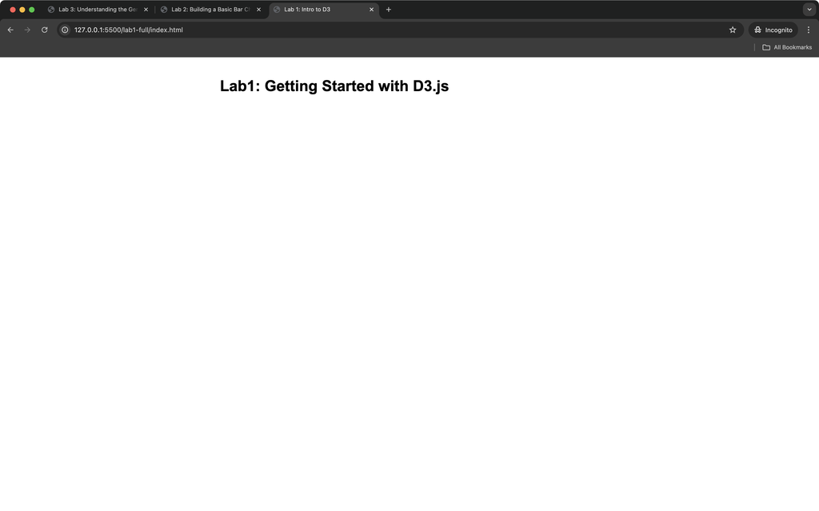

adding SVG

Wait! There is still nothing? This is because the svg is transparent, but if you use Developer Tools to inspect it, it should be there.

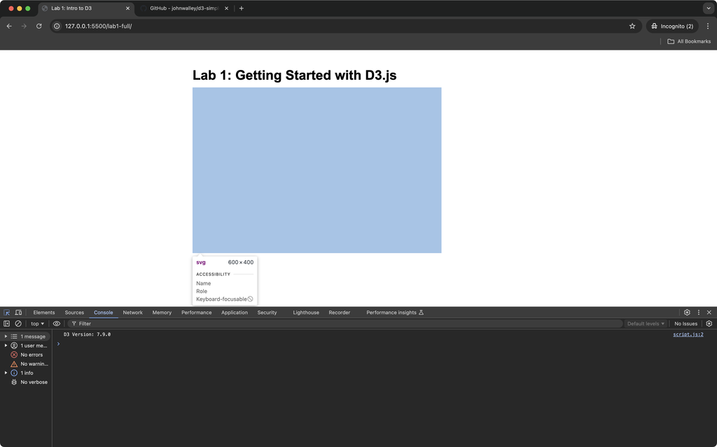

inspecting SVG

We add a border to the svg. You can add this using `.attr()` or `.style()`. Here I add a few lines to `css/styles.css`. `#vis svg` means that we select the svg nested under `#vis`.

```css
#vis svg {
    margin: 2rem 0;
    border: 1px solid #ccc; /*otherwise you can't see this part*/
}
```

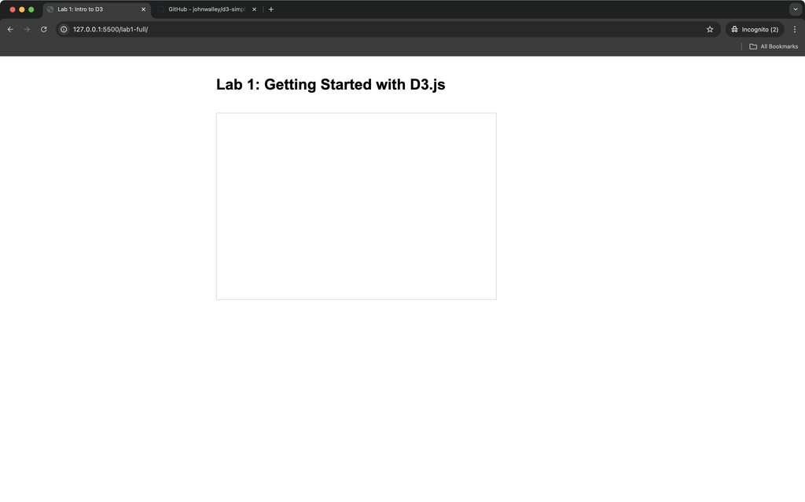

SVG with border

Draw with a simple circle

```javascript
svg.append('circle')
    //center of the circle
    .attr('cx', width/2)
    .attr('cy', height/2)
    // radius of the circle
    .attr('r', r)
    // color of the circle
    .style('fill', 'steelblue');
```

### Understanding D3 selections

- `d3.select()`: Selects a single element (It’s much like `queryselector()`, JQuery’s `$()`, or React.js’s `select()`)
- Method chaining: Each method returns a `selection`
- `.attr()`: Sets attributes
- `.style()`: Sets CSS properties

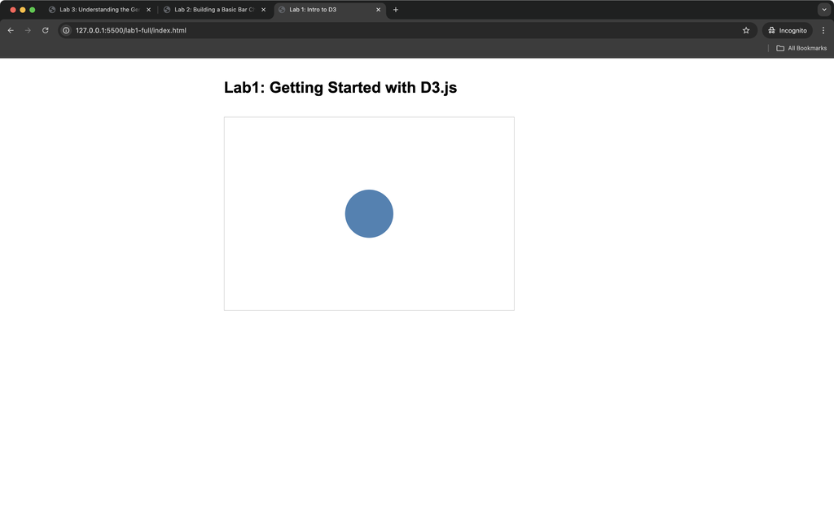

Adding a circle

## Part 3: Multiple circles and one rectangle (30 min)

In this part, you’ll create three circles and one square. The shapes will be arranged in a specific way.

### Adding three circles

1. Position the circles at:
   - Left circle: `width * 0.25`
   - Middle circle: `width * 0.5`
   - Right circle: `width * 0.75`
2. All circles should be vertically centered (`height * 0.5`)
3. Each circle should have a different color
4. All circles should have the same radius

### Adding one rectangle (`svg.append('rect')`)

1. Position a square above the middle circle
2. The square should have the same color as the middle circle, and its center is aligned with the middle circle
3. The square’s width and height should be equal

### Rectangle attributes

- Reference: https://d3-graph-gallery.com/graph/shape.html
- `x` and `y`: Define the top-left corner
- `width` and `height`: Define the size; for a square, make `width` equal to `height`
- To center the rectangle above the circle:
  - `x`: Subtract half the square width from the circle’s center
  - `y`: Position above the circle with some padding

### Understanding SVG coordinates

- The origin (0,0) is at the **top-left** corner
- X increases from left to right
- Y increases from top to bottom
- All positions are relative to the top-left corner
- Units are in pixels by default

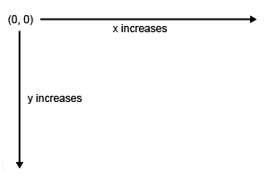

SVG coordinates

If you need a reference, here is the result after these steps.

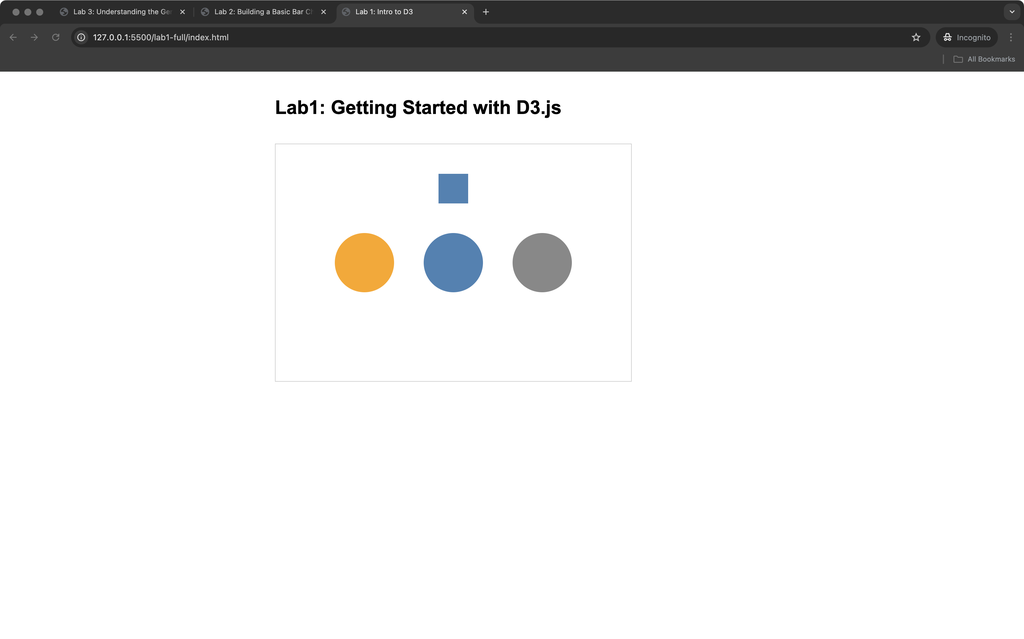

Results without any exercises

### Exercises

1. Modify the square size and maintain centering (required)
2. Try different color combinations (required)
3. Add strokes to all shapes (required)
4. Draw more shapes to generate a meaningful pattern (optional; you can do these by adding another `svg` or using a different `js` file.)

## Part 4: Data binding (optional)

Tired of copy-and-paste? Or maybe you wrote a loop? We will formally introduce D3’s data binding in the next lab. However, you can try the following code.

```javascript
// Sample data
const data = [
    {x: width * .25, color: 'orange'},
    {x: width * .5, color: 'steelblue'},
    {x: width * .75, color: '#888888'}
]

// Create circles based on data
svg.selectAll('circle')
    .data(data)
    .join('circle')
    .attr('cx', (d, i) => d.x)
    .attr('cy', height/2)
    .attr('r', d => r)
    .attr('class', 'circle')
    .style('fill', (d, i) => d.color);
```

## Checklist ✓

### Setup (same as Lab 0; not graded)

Project folder structure created  
index.html created with proper structure  
D3.js successfully loaded (check console)  
CSS file linked and working  
JavaScript file linked and executing  
Save your code to GitHub (optional)

### Circles and squares

SVG canvas created  
No console errors  
At least three circles and one square  
Circles are horizontally spaced at 1/4, 1/2, and 3/4 of width  
Circles are vertically centered  
Each circle has a different color  
Square is present above middle circle  
Square is properly centered  
All shapes are visible and not overlapping

### From the exercises

Modify the square size and maintain centering  
Try at least one different color  
Add strokes to all shapes

### Submission process

- Raise your hand ✋
- Show the working webpage (three circles of different colors, one square)
- Show your project structure in VS code; let us skim your `script.js`
- Any additional features implemented
- Confirm your name

### Notes for TAs

Please grade based on the checklist. If students are obviously missing something in their work:

- instead of taking some points off, first ask them to work on it again and submit it later
- if the student insists that they want to submit, take **5 pts off** for one feature

## Troubleshooting

1. **Nothing shows up?**
   - Check console for errors
   - Verify D3 is loaded
   - Check element IDs match
2. **Circles not appearing?**
   - Check SVG dimensions
   - Confirm attributes are set correctly
3. **Styles not working?**
   - Check CSS file path
   - Verify class names
   - Inspect elements in DevTools
4. **Rectangle not cntered**
   - Make sure to subtract half the square’s width from the x position
   - Example: `width * 0.5 - squaretwidth/2`
5. **Shapes overlapping**
   - Check your coordinates calculations
   - Verify the size values
6. **Colors not matching**
   - Store colors in variables to ensure consistency
   - Use the same color reference for related shapes
   - Console.log colors to verify values

## Additional resources

- [D3.js Documentation](https://d3js.org/)
- [SVG Basics](https://developer.mozilla.org/en-US/docs/Web/SVG)
- [D3 Selection Documentation](https://github.com/d3/d3-selection)